```python
# General libraries
import pandas as pd
import numpy as np
import matplotlib.pyplot as plt
from sklearn.model_selection import train_test_split
from sklearn.preprocessing import LabelEncoder, OneHotEncoder
from sklearn.feature_extraction.text import CountVectorizer, TfidfVectorizer, TfidfTransformer

import cv2

import re
from nltk import pos_tag
from nltk.corpus import stopwords, wordnet
from nltk.stem import WordNetLemmatizer
from nltk.tokenize import regexp_tokenize, RegexpTokenizer, word_tokenize

import tensorflow.keras as keras
from keras import initializers, regularizers, optimizers, layers
from keras.callbacks import ModelCheckpoint, ReduceLROnPlateau
from keras.layers import Dropout, Activation, Bidirectional, GlobalMaxPool1D, Input, Dense, LSTM, Embedding, Flatten, BatchNormalization, SpatialDropout1D, SimpleRNN, GRU, ConvLSTM2D, CuDNNLSTM, Conv2D
from keras.models import Sequential
from keras.preprocessing import text, sequence
from keras.regularizers import l2
from keras.utils import pad_sequences


from tensorflow.keras.callbacks import EarlyStopping, ReduceLROnPlateau
from tensorflow.keras.optimizers import Adam
from tensorflow.keras.preprocessing.text import Tokenizer


from keras.layers.convolutional import Conv1D, MaxPooling1D

# QOL libraries
import os
import seaborn as sns
import random
from wordcloud import WordCloud, STOPWORDS, ImageColorGenerator
from PIL import Image

random.seed(13)
```

# Twitter Tweets Sentiment

- Problem and Data Description
- EDA and Data Preprocessing
- Model Architecture
- Results and Analysis
- Conclusion

## Problem and Data Description

This notebook resolves around a Deep Learning problem utilizing the [Twitter Tweets Sentiment Dataset](https://www.kaggle.com/datasets/yasserh/twitter-tweets-sentiment-dataset/data). The main idea of the problem is that generally speaking tweets can be categorized into three main sentiments: positive, neutral, and negative. These sentiment refers to the summarized emotion that the poster of said tweet is portraying in his text. For example, a positive tweet could be someone celebrating the birth of a child, while a negative tweet could be a person lamenting the loss of a close family member. On the other hand, a neutral tweet is more or less anything in between that does not majorly sway towards one side or the other.

The data consists of a dataset with 4 columns, and has roughly 27.5k tweets to train with. The columns are:

- textID - an unique identifier string for each individual tweet
- text - a string consisting of the text in the tweet
- selected_text - a string consisting of the main part of the tweet
- sentiment - a categorical string that describes the sentiment of the tweet

```python
path = 'data/'

df = pd.read_csv(path + 'Tweets.csv')
df.head()
```

|  | textID | text | selected_text | sentiment |
| --- | --- | --- | --- | --- |
| 0 | cb774db0d1 | I`d have responded, if I were going | I`d have responded, if I were going | neutral |
| 1 | 549e992a42 | Sooo SAD I will miss you here in San Diego!!! | Sooo SAD | negative |
| 2 | 088c60f138 | my boss is bullying me... | bullying me | negative |
| 3 | 9642c003ef | what interview! leave me alone | leave me alone | negative |
| 4 | 358bd9e861 | Sons of ****, why couldn`t they put them on t... | Sons of ****, | negative |

```python
df.shape
```

```
(27481, 4)
```

## Exploratory Data Analysis and Data Preprocessing

First we can explore a bit on how each columns' contents look like.

```python
df['text'].sample(5)
```

```
1956     Done! Goin home to eat dindin and contemplate ...
997       Since the demise of Woolworths it isn`t easy ...
2015     Have $#@&!!! Malware on my work PC!  I miss ha...
8011      I still have plenty of food left here! Thanks...
12106    Why does flickr no longer recognize my e-mail ...
Name: text, dtype: object
```

```python
df['selected_text'].sample(5)
```

```
22526       despite the heater it gets too chilly at night
23552                    Last time i`ll see her in a while
323                                              I`m broke
7046                      Adventures with jamie and bethhh
21417    Morning all  sun is shining, birds are singing...
Name: selected_text, dtype: object
```

Now we can do the usual checks of duplications and NA values. Fortunately there are no duplicate rows, and only one single row with NA values which we will simply drop as there will be minimal impact.

```python
df[df.duplicated()]
```

|  | textID | text | selected_text | sentiment |
| --- | --- | --- | --- | --- |

```python
df.isna().sum()
```

```
textID           0
text             1
selected_text    1
sentiment        0
dtype: int64
```

```python
df_cln = df.dropna(subset = ['text'])

df_cln.isna().sum()/ len(df_cln)
```

```
textID           0.0
text             0.0
selected_text    0.0
sentiment        0.0
dtype: float64
```

Now we can check for signs of class imbalance. There does not appear to be a large imbalance between the three different labels so we can safely proceed.

```python
df_cln['sentiment'].value_counts()
```

```
neutral     11117
positive     8582
negative     7781
Name: sentiment, dtype: int64
```

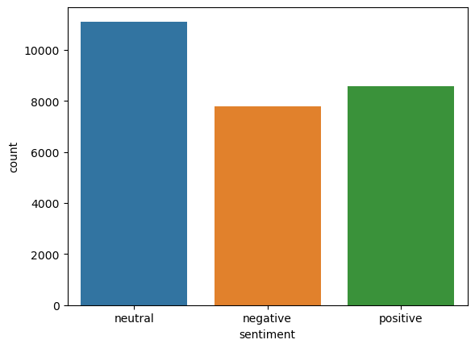

```python
sns.countplot(x = 'sentiment', data = df_cln)
```

As we are going to use NLP techniques, we must prepare the text data in a way to best suit it. We will do the following to help clean the text:

1. Splitting the text up into words
2. Turning the words lowercase
3. Removing punctuation
4. Removing @'s which are twitter jargon
5. Removing leftover numbers
6. Removing words with accents
7. Removing stop words and more twitter jargon
8. Change targets in string to 'product_target' if a target exists
9. Removing empty strings
10. Joining all the strings together into one

We will also be mapping integers to our sentiments to aid in the encoding process, with 'positive', 'neutral', and 'negative' becoming 1, 0, and -1 respectively. As the cleaned up version of our 'text' column is sufficient, we will also be dropping the 'selected_text' column as well.

```python
def clean(txt):
    sw = stopwords.words('english')
    sw.extend(['link', 'rt', 'get'])
    punctuation = '!"$%&\'()*+,-./:;<=>?[\\]^_`{|}~“!#'
    no_accents_re = re.compile('^[a-z]+$')
    accents = ['á', 'â', 'ã', 'à', 'å', 'ª', 'ç', 'è', '¼', '¾', 'î', 'ï', 'ì', 'ó', 'ö', 'ð', 'ü', 'ù', 'û', 'ý']
    twitter_re = re.compile('[@][a-zA-Z]*')
    num_re = re.compile('^\d+$')

    if isinstance(txt, list):
        t = txt[0].split(' ')
    else:
        t = txt.split(' ')
    t = [w.lower() for w in t]
    t = [w.translate(w.maketrans('','', punctuation)) for w in t]
    t = [w for w in t if not twitter_re.match(w)]
    t = [w for w in t if not num_re.match(w)]
    t = [w for w in t if no_accents_re.match(w)]
    t = [w for w in t if w not in sw]
    if isinstance(txt, list):
        t = ['product_target' if w in product_target(txt[1]) else w for w in t]
        if txt[1].lower() in ['android app', 'ipad or iphone app']:
            t = [w for w in t if w != 'app']
    t = [w for w in t if w]

    return ' '.join(t)


def emotion_label(txt):
    if txt == 'positive':
        return 1
    elif txt == 'neutral':
        return 0
    elif txt == 'negative':
        return -1
    else:
        print('Unknown emotion')

df_cln['txt_f'] = df_cln['text'].apply(clean)
df_cln['sentiment_f'] = df_cln['sentiment'].apply(emotion_label)
```

After the text is cleaned, we can check the text contents of the three different sentiments.

First we check the typical word count between the three types of tweets. While there is some class imbalance, we can tell that positive and negative tweets have a higher average word count compared to neutral tweets.

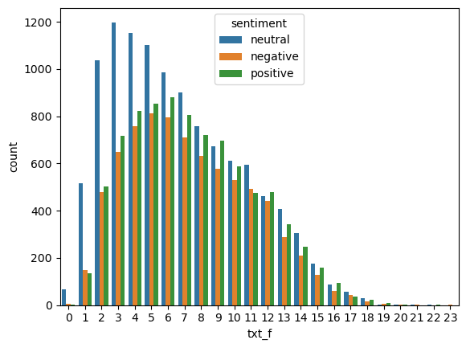

```python
sns.countplot(x = df_cln['txt_f'].str.split().apply(len), hue = df_cln['sentiment'])
```

```python
df_neutral = pd.DataFrame(' '.join(df_cln[df_cln['sentiment'] == 'neutral']['txt_f'].values).split(), columns = ['words'])
df_negative = pd.DataFrame(' '.join(df_cln[df_cln['sentiment'] == 'negative']['txt_f'].values).split(), columns = ['words'])
df_positive = pd.DataFrame(' '.join(df_cln[df_cln['sentiment'] == 'positive']['txt_f'].values).split(), columns = ['words'])
```

Next we can check the word distribution of the individual sentiments.

First we have neutral words.

[figure not shown]

```python
wordcloud_neutral = WordCloud(max_font_size = 50, max_words = 1000, background_color = 'white').generate(df_neutral['words'].str.cat(sep = ' '))
fig = plt.figure()
plt.imshow(wordcloud_neutral, interpolation='bilinear')
plt.axis("off")
plt.show()
```

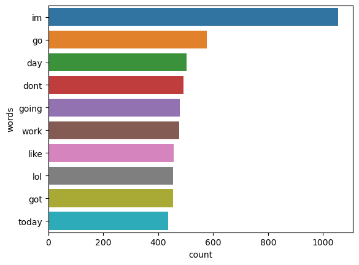

```python
sns.countplot(y = 'words', data = df_neutral, order = df_neutral['words'].value_counts().iloc[:10].index)
```

Then negative words.

[figure not shown]

```python
wordcloud_negative = WordCloud(max_font_size = 50, max_words = 1000, background_color = 'white').generate(df_negative['words'].str.cat(sep = ' '))
fig = plt.figure()
plt.imshow(wordcloud_negative, interpolation='bilinear')
plt.axis("off")
plt.show()
```

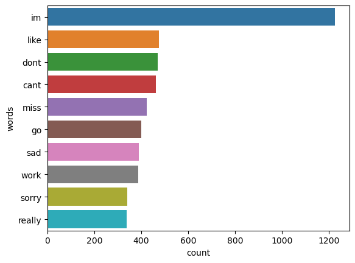

```python
sns.countplot(y = 'words', data = df_negative, order = df_negative['words'].value_counts().iloc[:10].index)
```

And lastly positive words.

[figure not shown]

```python
wordcloud_positive = WordCloud(max_font_size = 50, max_words = 1000, background_color = 'white').generate(df_positive['words'].str.cat(sep = ' '))
fig = plt.figure()
plt.imshow(wordcloud_positive, interpolation='bilinear')
plt.axis("off")
plt.show()
```

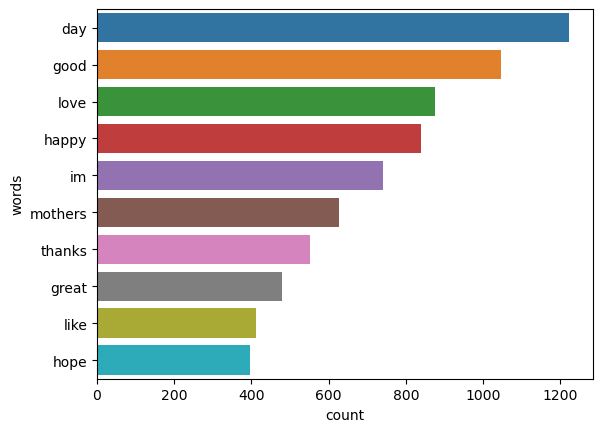

```python
sns.countplot(y = 'words', data = df_positive, order = df_positive['words'].value_counts().iloc[:10].index)
```

Here is how our data looks after pre-processing is completed.

```python
df_f = df_cln[['text','txt_f', 'sentiment', 'sentiment_f']]
df_f.head()
```

|  | text | txt_f | sentiment | sentiment_f |
| --- | --- | --- | --- | --- |
| 0 | I`d have responded, if I were going | id responded going | neutral | 0 |
| 1 | Sooo SAD I will miss you here in San Diego!!! | sooo sad miss san diego | negative | -1 |
| 2 | my boss is bullying me... | boss bullying | negative | -1 |
| 3 | what interview! leave me alone | interview leave alone | negative | -1 |
| 4 | Sons of ****, why couldn`t they put them on t... | sons couldnt put releases already bought | negative | -1 |

The last data preprocessing step will be to tokenize our text. This turns our text data into something that makes more sense for the machine model to read. We will also be OneHotEncoding our sentiment categories as well. While we are at it, we will also split our data into a training set and a validation set.

```python
tokenizer = text.Tokenizer(num_words = 30000, split = ' ')
tokenizer.fit_on_texts(list(df_f['txt_f'].values))

integer_encoded = LabelEncoder().fit_transform(df_f['sentiment_f'])
integer_encoded = integer_encoded.reshape(len(integer_encoded), 1)
onehot_encoder = OneHotEncoder(sparse_output=False)

X = pad_sequences(tokenizer.texts_to_sequences(df_f['txt_f'].values))
y = onehot_encoder.fit_transform(integer_encoded)

X_train, X_test, y_train, y_test = train_test_split(X, y, random_state = 13, test_size = 0.2)

earlystopper = EarlyStopping(monitor='val_loss', patience=2, verbose=1, restore_best_weights=True)
reducel = ReduceLROnPlateau(monitor='val_loss', patience=1, verbose=1, factor=0.1)
```

## Model Architecture

As we are undergoing Natural Language Processing tasks in this scenario, the best model architecture for us to use will be Recurrent Neural Networks. This is due to NLP tasks works with not just the individual words but how they fit together as a whole, thus maintaining the context of each text sentence is something that we cannot ignore. RNNs work well in this situation as they are used for handling sequential data, which means it keeps track of the order of individual words as it progresses. RNN is also able to utilize the word embedding we did earlier with the tokenizer which will greatly speed up the learning process.

We will be attempting four different RNN models in this project and testing to see which one provides the best results:

- SimpleRNN
- LSTM
- Bidirectional LSTM
- GRU

SimpleRNN; a barebones basic model for RNN purposes.

```python
dictionary_length = len(tokenizer.word_index.keys()) + 1
sequence_len = 64

model = Sequential()

model.add(Embedding(dictionary_length, sequence_len))
model.add(SimpleRNN(50))
model.add(Dense(3, activation = 'sigmoid'))

model.compile(Adam(learning_rate = 0.001), loss='categorical_crossentropy', metrics=['accuracy'])

history_1 = model.fit(X_train, y_train,
                    epochs = 5,
                    batch_size = 32,
                    validation_data = (X_test, y_test))
```

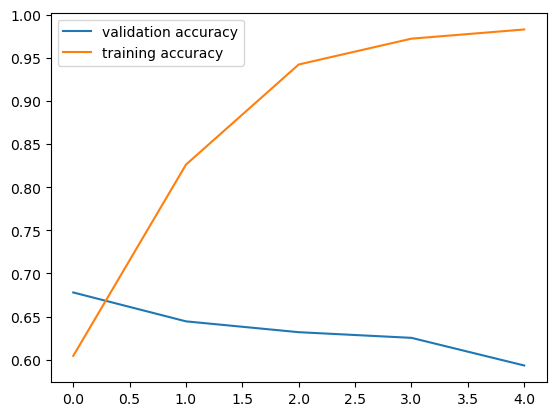

```python
plt.plot(history_1.history['val_accuracy'], label = 'validation accuracy')
plt.plot(history_1.history['accuracy'], label = 'training accuracy')
plt.legend()
plt.show()
```

LSTM; Long Short-Term Memory, hasa emphasis on keeping track of past data.

```python
dictionary_length = len(tokenizer.word_index.keys()) + 1
sequence_len = 64

model = Sequential()

model.add(Embedding(dictionary_length, sequence_len))
model.add(LSTM(50))
model.add(Dense(3, activation = 'sigmoid'))

model.compile(Adam(learning_rate = 0.001), loss='categorical_crossentropy', metrics=['accuracy'])

history_2 = model.fit(X_train, y_train,
                    epochs = 5,
                    batch_size = 32,
                    validation_data = (X_test, y_test))
```

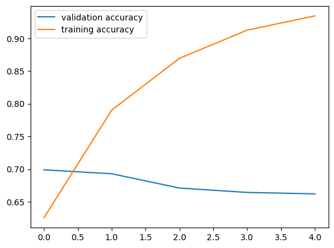

```python
plt.plot(history_2.history['val_accuracy'], label = 'validation accuracy')
plt.plot(history_2.history['accuracy'], label = 'training accuracy')
plt.legend()
plt.show()
```

Bidirectional LSTM, upgraded version of LSTM that processes in both directions for a better understanding of the context.

```python
dictionary_length = len(tokenizer.word_index.keys()) + 1
sequence_len = 64

model = Sequential()

model.add(Embedding(dictionary_length, sequence_len))
model.add(Bidirectional(LSTM(50)))
model.add(Dense(3, activation = 'sigmoid'))

model.compile(Adam(learning_rate = 0.001), loss='categorical_crossentropy', metrics=['accuracy'])

history_3 = model.fit(X_train, y_train,
                    epochs = 5,
                    batch_size = 32,
                    validation_data = (X_test, y_test))
```

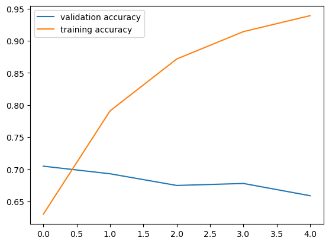

```python
plt.plot(history_3.history['val_accuracy'], label = 'validation accuracy')
plt.plot(history_3.history['accuracy'], label = 'training accuracy')
plt.legend()
plt.show()
```

GRU, similar to LSTM but lighter and faster.

```python
dictionary_length = len(tokenizer.word_index.keys()) + 1
sequence_len = 64

model = Sequential()

model.add(Embedding(dictionary_length, sequence_len))
model.add(GRU(50))
model.add(Dense(3, activation = 'sigmoid'))

model.compile(Adam(learning_rate = 0.001), loss='categorical_crossentropy', metrics=['accuracy'])

history_4 = model.fit(X_train, y_train,
                    epochs = 5,
                    batch_size = 32,
                    validation_data = (X_test, y_test))
```

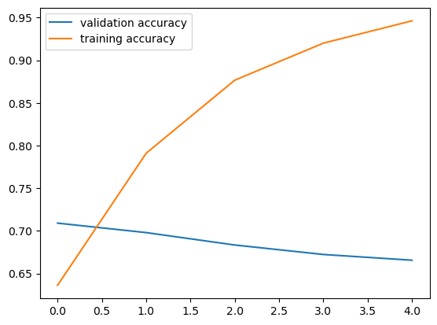

```python
plt.plot(history_4.history['val_accuracy'], label = 'validation accuracy')
plt.plot(history_4.history['accuracy'], label = 'training accuracy')
plt.legend()
plt.show()
```

From all the models we've seen, other than the base SimpleRNN model they all seem to be around the same performance. Thus we will be proceeding with the LSTM model. Afterwards, we can attempt to boost our performance a bit more with hyperparameter tuning.

Multiple LSTM layers.

```python
dictionary_length = len(tokenizer.word_index.keys()) + 1
sequence_len = 64

model = Sequential()

model.add(Embedding(dictionary_length, sequence_len))
model.add(LSTM(50, return_sequences = True))
model.add(LSTM(25))

model.add(Dense(3, activation = 'sigmoid'))

model.compile(Adam(learning_rate = 0.001), loss='categorical_crossentropy', metrics=['accuracy'])

history_5 = model.fit(X_train, y_train,
                    epochs = 5,
                    batch_size = 32,
                    validation_data = (X_test, y_test))
```

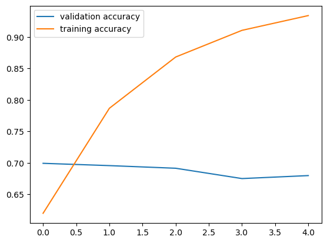

```python
plt.plot(history_5.history['val_accuracy'], label = 'validation accuracy')
plt.plot(history_5.history['accuracy'], label = 'training accuracy')
plt.legend()
plt.show()
```

Extra Dense layers.

```python
dictionary_length = len(tokenizer.word_index.keys()) + 1
sequence_len = 64

model = Sequential()

model.add(Embedding(dictionary_length, sequence_len))
model.add(LSTM(50, return_sequences = True))
model.add(LSTM(25))
model.add(Dense(50, activation = 'relu'))
model.add(Dense(3, activation = 'softmax'))

model.compile(Adam(learning_rate = 0.001), loss='categorical_crossentropy', metrics=['accuracy'])

history_6 = model.fit(X_train, y_train,
                    epochs = 5,
                    batch_size = 32,
                    validation_data = (X_test, y_test))
```

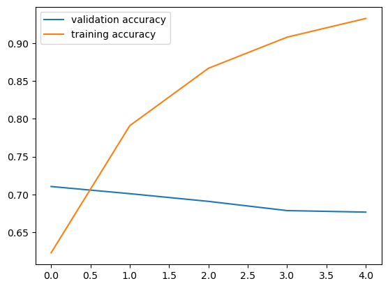

```python
plt.plot(history_6.history['val_accuracy'], label = 'validation accuracy')
plt.plot(history_6.history['accuracy'], label = 'training accuracy')
plt.legend()
plt.show()
```

Spatial Dropout layers.

```python
dictionary_length = len(tokenizer.word_index.keys()) + 1
sequence_len = 64

model = Sequential()

model.add(Embedding(dictionary_length, sequence_len))
model.add(SpatialDropout1D(0.2))
model.add(LSTM(100, dropout=0.2, recurrent_dropout=0.2))
model.add(Dense(50, activation = 'relu'))
model.add(Dense(3, activation='softmax'))

model.compile(Adam(learning_rate = 0.001), loss='categorical_crossentropy', metrics=['accuracy'])

history_7 = model.fit(X_train, y_train,
                    epochs = 5,
                    batch_size = 32,
                    validation_data = (X_test, y_test))
```

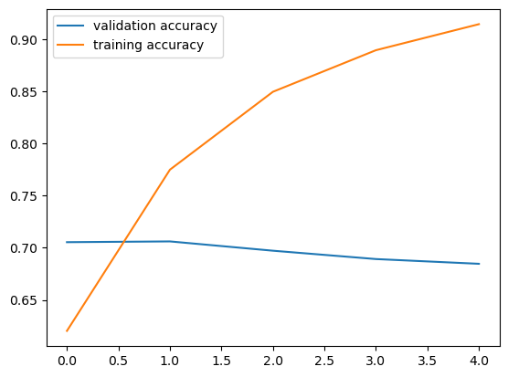

```python
plt.plot(history_7.history['val_accuracy'], label = 'validation accuracy')
plt.plot(history_7.history['accuracy'], label = 'training accuracy')
plt.legend()
plt.show()
```

Multiple Dropout layers.

```python
dictionary_length = len(tokenizer.word_index.keys()) + 1
sequence_len = 64
dropout = 0.2

model = Sequential()

model.add(Embedding(dictionary_length, sequence_len))
model.add(Dropout(dropout))
model.add(LSTM(50))
model.add(Dropout(dropout))
model.add(Dense(50, activation = 'relu'))
model.add(Dropout(dropout))
model.add(Dense(3, activation = 'softmax'))

model.compile(Adam(learning_rate = 0.001), loss='categorical_crossentropy', metrics=['accuracy'])

history_8 = model.fit(X_train, y_train,
                    epochs = 5,
                    batch_size = 32,
                    validation_data = (X_test, y_test))
```

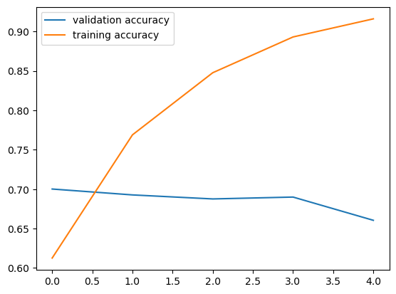

```python
plt.plot(history_8.history['val_accuracy'], label = 'validation accuracy')
plt.plot(history_8.history['accuracy'], label = 'training accuracy')
plt.legend()
plt.show()
```

## Results and Analysis

With the results of all of our different models, we can consolidate them to rank them based on our metric of choice. In this case, we will be using the accuracy score on the validation dataset to score each model.

```python
hst_model = [ history_1, history_2, history_3, history_4]
hst_hpt = [ history_5, history_6, history_7, history_8]
hst_model_val = [ max(i.history['val_accuracy']) for i in hst_model ]
hst_hpt_val = [ max(i.history['val_accuracy']) for i in hst_hpt ]
df_model_hst = pd.DataFrame({'model': range(0,4), 'val_accuracy': hst_model_val})
df_hpt_hst = pd.DataFrame({'model': range(0,4), 'val_accuracy': hst_hpt_val})

df_model_hst['model'] += 1
df_hpt_hst['model'] += 5
```

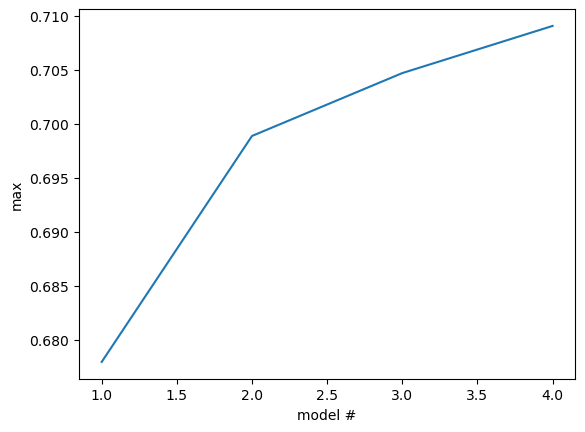

```python
plt.plot(range(1,5), hst_model_val)
plt.xlabel('model #')
plt.ylabel('max')
plt.show()
```

```python
df_model_hst.sort_values(by=['val_accuracy'], ascending = False)
```

|  | model | val_accuracy |
| --- | --- | --- |
| 3 | 4 | 0.709061 |
| 2 | 3 | 0.704694 |
| 1 | 2 | 0.698872 |
| 0 | 1 | 0.677948 |

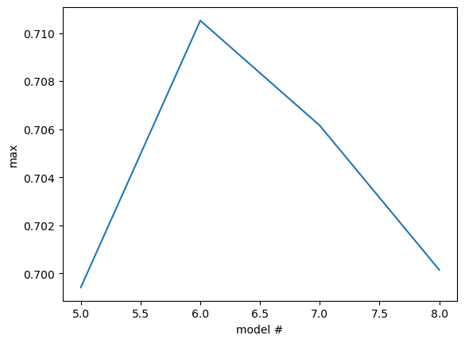

```python
plt.plot(range(5,9), hst_hpt_val)
plt.xlabel('model #')
plt.ylabel('max')
plt.show()
```

```python
df_hpt_hst.sort_values(by=['val_accuracy'], ascending = False)
```

|  | model | val_accuracy |
| --- | --- | --- |
| 1 | 6 | 0.710517 |
| 2 | 7 | 0.706150 |
| 3 | 8 | 0.700146 |
| 0 | 5 | 0.699418 |

The 6th model ended up with the highest validation accuracy score, and thus will be our model of choice in this scenario. This is the model that had three hyperparameter changes of note, mainly having multiple LSTM layers, multiple Dense layers, as well as having a 'relu' activation function in the hidden layer as well as a 'softmax' activation function for the output layer. The LSTM model was chosen as the performance of all models other than the SimpleRNN were very close to each other, and the other models were all variations of the LSTM so just stuck with LSTM in the end. In addition, the 'softmax' activation function makes perfect sense as it is an activation function that is preferable over the typical 'sigmoid' when there are multiple classes to predict, which in this case is true with our three potential choices for our label.

## Conclusion

The result of testing the different models led to our best model being one that consists of multiples of both LSTM and Dense layers. The main takeaway from this project is that simply increasing the number of potential labels from 2 in a binary situation to any greater number will significantly increase the complexity and difficulty in getting accurate predictions. There were two separate ideas that could be helpful to improve performance in case this project needed to be redone, and the first would be to remove the 'neutral' sentiments. While this would greatly lower the amount of data we can work with, depending on the situation it could be beneficial as going back down to two potential labels would greatly improve model performance. As an added bonus, typically 'neutral' sentiment tweets are not as interesting or important as tweets with a 'positive' or 'negative' connotation so could be thrown out without much loss. The second would be to tokenize the words to include multi-word phrases, so instead of having the values of "happy" and "day it would show up as "happy day". While this would exponentially increase the amount of data used for training, it could potentially help capture context in tweets much better than with just single word tokenization.

```python
dictionary_length = len(tokenizer.word_index.keys()) + 1
sequence_len = 64

model_f = Sequential()

model_f.add(Embedding(dictionary_length, sequence_len))
model_f.add(LSTM(50, return_sequences = True))
model_f.add(LSTM(25))
model_f.add(Dense(50, activation = 'relu'))
model_f.add(Dense(3, activation = 'softmax'))

model_f.compile(Adam(learning_rate = 0.001), loss='categorical_crossentropy', metrics=['accuracy'])

history_f = model_f.fit(X_train, y_train,
                    epochs = 5,
                    batch_size = 32,
                    validation_data = (X_test, y_test))
```